# Fase1_report

Ana Filipa Moreira, Diana Oliveira, Márcia Silva e Rodolfo Ferreira

2026-03-30

## Objetivos da Fase 1

Nesta primeira fase pretende-se:

- descrever os dados, a sua origem e relevância;
- realizar a preparação e o pré-processamento inicial dos dados;
- efetuar uma sumarização dos dados com estatística descritiva e gráficos exploratórios;
- realizar análise estatística univariada, análise de expressão diferencial e análise de enriquecimento.

## Estrutura da análise

A análise será organizada em diferentes scripts:

- 01_load_data.R — carregamento dos dados
- 02_preprocessing_clinical.R — limpeza dos dados clínicos
- 03_preprocessing_expression.R — preparação da matriz de expressão
- 04_merge_data.R — integração dos dados
- 05_exploratory_analysis.R — exploração inicial
- 06_statistical_analysis.R — análise estatística e expressão diferencial

## Introdução

Este trabalho tem como objetivo a análise de um conjunto de dados de expressão génica no contexto do adenocarcinoma do pulmão (Lung Adenocarcinoma, LUAD), utilizando R e ferramentas adequadas para análise de dados biológicos.

O conjunto de dados selecionado foi obtido a partir do cBioPortal, correspondendo ao estudo **Lung Adenocarcinoma (TCGA PanCancer Atlas)**. Este estudo inclui informação clínica dos pacientes, informação ao nível da amostra tumoral e dados de expressão génica obtidos por RNA-seq.

## Origem e relevância dos dados

Os dados utilizados neste trabalho foram obtidos do projeto The Cancer Genome Atlas (TCGA), que disponibiliza informação clínica e molecular de diversos tipos de cancro. Neste estudo, foram analisados dados de expressão génica e variáveis clínicas de pacientes com carcinoma pulmonar de não pequenas células (LUAD).

A integração destes dados permite investigar diferenças biológicas entre grupos de pacientes, nomeadamente entre indivíduos jovens e idosos, contribuindo para uma melhor compreensão da progressão da doença e apoiando abordagens de medicina de precisão.

Foram utilizados três ficheiros principais:

- data_clinical_patient.txt: informação clínica ao nível do paciente
- data_clinical_sample.txt: informação ao nível da amostra tumoral
- data_mrna_seq_v2_rsem.txt: dados de expressão genética

```r
source("../scripts/01_load_data.R")
```

De forma preliminar, os dados carregados incluem:

```r
dim(clinical_patient)
```

```
## [1] 566  38
```

```r
dim(clinical_sample)
```

```
## [1] 566  19
```

```r
dim(expr)
```

```
## [1] 20531   512
```

### Variáveis Identificadoras

Incluem identificadores únicos das amostras e dos pacientes:

- **PATIENT_ID** – identificador do paciente (ex: TCGA-05-4244)
- **SAMPLE_ID** – identificador da amostra (ex: TCGA-05-4244-01)

Estas variáveis são do tipo **character** e são utilizadas para integração entre dados clínicos, moleculares e de expressão génica.

### Variáveis Clínicas e Categóricas

Incluem informação demográfica, clínica e de caracterização tumoral:

- **CANCER_TYPE_ACRONYM** – tipo de cancro (ex: LUAD)
- **SEX** – sexo do paciente (Male/Female)
- **AJCC_PATHOLOGIC_TUMOR_STAGE** – estádio tumoral global (Stage I–IV)
- **PATH_T_STAGE** – componente T do estadiamento (tamanho/extensão do tumor)
- **PATH_N_STAGE** – componente N (envolvimento ganglionar)
- **PATH_M_STAGE** – componente M (metástases)
- **OS_STATUS** – estado de sobrevivência (LIVING/DECEASED)
- **PFS_STATUS** – estado de progressão da doença (CENSORED/PROGRESSION)
- **GENETIC_ANCESTRY_LABEL** – ancestralidade genética (ex: EUR)

Estas variáveis são do tipo **character**, sendo algumas **ordinais** (ex: estádios TNM e AJCC).

### Variáveis Numéricas Clínicas

Incluem métricas quantitativas associadas ao paciente e ao prognóstico:

- **AGE** – idade do paciente no diagnóstico (anos)
- **OS_MONTHS** – tempo de sobrevivência global (meses)
- **PFS_MONTHS** – tempo até progressão da doença (meses)

Estas variáveis são do tipo **numérico contínuo**.

### Variáveis Moleculares

Incluem métricas associadas à biologia tumoral:

- **ANEUPLOIDY_SCORE** – grau de instabilidade cromossómica
- **MSI_SCORE_MANTIS** – score de instabilidade de microssatélites
- **TMB_NONSYNONYMOUS** – carga mutacional tumoral (TMB)

Estas variáveis são do tipo **numérico contínuo** e refletem diferentes mecanismos de instabilidade genómica.

### Variáveis de Expressão Génica

Correspondem ao dataset **expr_final**:

- **Gene_ID / Gene Symbol** – identificador do gene (ex: UBE2Q2P2, HMGB1P1)
- **Amostras (colunas)** – cada coluna corresponde a uma amostra (ex: TCGA-05-4244-01), compatível com **SAMPLE_ID** Os valores da matriz representam:
- níveis de expressão génica normalizados (**RSEM**)
- transformados em **escala log2**, o que reduz assimetria e estabiliza a variância

## Preprocessamento dos dados clínicos

```r
source("../scripts/02_preprocessing_clinical.R")
```

```
## Dimensão do dataset clinical_patient limpo: 566 13
## Dimensão do dataset clinical_sample limpo: 566 6
## 'data.frame':    566 obs. of  13 variables:
##  $ PATIENT_ID                 : chr  "TCGA-05-4244" "TCGA-05-4249" "TCGA-05-4250" "TCGA-05-4382" ...
##  $ CANCER_TYPE_ACRONYM        : Factor w/ 1 level "LUAD": 1 1 1 1 1 1 1 1 1 1 ...
##  $ AGE                        : num  70 67 79 68 66 70 58 76 76 65 ...
##  $ SEX                        : Factor w/ 2 levels "Female","Male": 2 2 1 2 2 2 1 2 2 2 ...
##  $ AJCC_PATHOLOGIC_TUMOR_STAGE: Factor w/ 9 levels "STAGE I","STAGE IA",..: 9 3 7 3 7 2 3 8 8 6 ...
##  $ PATH_T_STAGE               : Factor w/ 9 levels "T1","T1A","T1B",..: 4 4 7 4 4 1 4 8 8 4 ...
##  $ PATH_N_STAGE               : Factor w/ 5 levels "N0","N1","N2",..: 3 1 2 1 3 1 1 3 2 2 ...
##  $ PATH_M_STAGE               : Factor w/ 5 levels "M0","M1","M1A",..: 2 1 1 1 1 1 1 1 1 1 ...
##  $ OS_STATUS                  : Factor w/ 2 levels "DECEASED","LIVING": 2 2 1 2 2 2 2 1 1 1 ...
##  $ OS_MONTHS                  : num  0 50.07 3.98 19.96 14.01 ...
##  $ PFS_STATUS                 : Factor w/ 2 levels "CENSORED","PROGRESSION": 1 1 1 2 2 1 2 1 1 1 ...
##  $ PFS_MONTHS                 : num  0 50.07 3.98 10.98 6.02 ...
##  $ GENETIC_ANCESTRY_LABEL     : Factor w/ 5 levels "AFR","AFR_ADMIX",..: 5 5 5 5 5 5 5 5 5 5 ...
## 'data.frame':    566 obs. of  6 variables:
##  $ PATIENT_ID       : chr  "TCGA-05-4244" "TCGA-05-4249" "TCGA-05-4250" "TCGA-05-4382" ...
##  $ SAMPLE_ID        : chr  "TCGA-05-4244-01" "TCGA-05-4249-01" "TCGA-05-4250-01" "TCGA-05-4382-01" ...
##  $ ANEUPLOIDY_SCORE : num  17 24 17 22 1 20 21 25 11 7 ...
##  $ SAMPLE_TYPE      : Factor w/ 1 level "Primary": 1 1 1 1 1 1 1 1 1 1 ...
##  $ MSI_SCORE_MANTIS : num  0.289 0.281 0.306 0.319 0.285 ...
##  $ TMB_NONSYNONYMOUS: num  6.4 10 10.5 51.73 3.97 ...
```

Nesta etapa foi realizada a limpeza e preparação dos dados clínicos e das amostras. Inicialmente, foram selecionadas apenas as variáveis relevantes para a análise, incluindo características demográficas, estádios tumorais e métricas associadas à sobrevivência e carga tumoral .

De seguida, valores vazios foram convertidos em valores ausentes (NA), e foram removidas entradas sem identificadores válidos de paciente ou amostra, garantindo a consistência dos dados. As variáveis numéricas foram convertidas para o formato adequado, permitindo a sua utilização em análises estatísticas.

Foi também efetuada a limpeza das variáveis de estado (como sobrevivência e progressão), removendo prefixos desnecessários, e as variáveis categóricas foram convertidas para o tipo factor, facilitando a sua utilização em modelos e visualizações.

Por fim, foram realizadas verificações básicas da estrutura dos dados, incluindo dimensões e distribuições das principais variáveis, assegurando a qualidade do dataset antes das etapas seguintes.

## Preparação da matriz de expressão

```r
source("../scripts/03_preprocessing_expression.R")
```

```
## Coluna de símbolo génico: Hugo_Symbol
## Coluna de Entrez ID: Entrez_Gene_Id
## Número de colunas identificadas como amostras: 510
## Dimensão inicial da matriz numérica: 20531 510
## Após remover genes sem ID: 20531 510
## Número total de NA na matriz: 0
## Genes com pelo menos 1 NA: 0
## Após remover genes com NA: 20531 510
## Após colapsar genes duplicados: 20524 510
## Após filtrar genes pouco expressos: 18420 510
## Após transformação log2: 18420 510
```

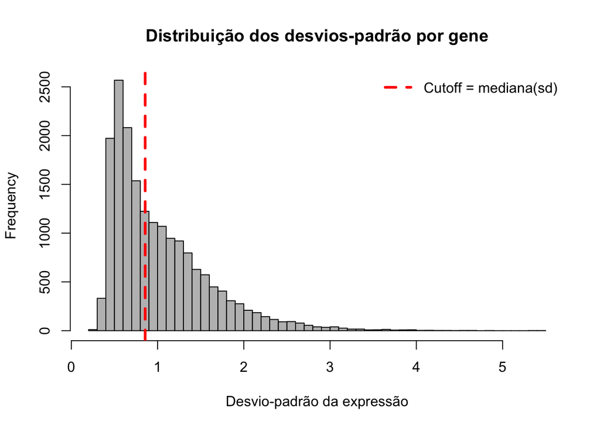

```
## Após filtro de flat patterns (SD > mediana): 9210 510
```

Nesta etapa foi realizada a preparação da matriz de expressão génica para análise. Inicialmente, foi identificada a coluna contendo os identificadores dos genes e selecionadas apenas as colunas correspondentes às amostras, excluindo possíveis colunas de anotação .

De seguida, os dados foram convertidos para formato numérico e organizados numa matriz com genes nas linhas e amostras nas colunas. Foram removidos genes sem identificador válido e duplicados, garantindo a consistência da matriz.

Posteriormente, foram eliminados genes com valores em falta (NA), e aplicada uma filtragem para remover genes pouco expressos, mantendo apenas aqueles com expressão relevante em pelo menos 10% das amostras.

Por fim, foi aplicada uma transformação logarítmica (log2), com o objetivo de estabilizar a variância dos dados e facilitar análises exploratórias, como PCA e visualizações. Foram ainda realizadas verificações descritivas para avaliar a distribuição dos valores e a consistência entre amostras.

## Integração dos dados

```r
source("../scripts/04_merge_data.R")
```

```
## Número de amostras em comum: 510
## Dimensão expr_final: 9210 510
## Dimensão clin_final: 510 18
## Alinhamento correto entre expressão e clínico: TRUE
```

Nesta etapa foi realizada a integração dos dados clínicos e da matriz de expressão génica. Inicialmente, os dados clínicos ao nível do paciente e da amostra foram combinados com base no identificador do paciente (PATIENT_ID), criando um dataset clínico unificado .

De seguida, os identificadores das amostras na matriz de expressão foram ajustados para garantir consistência de formato, permitindo a correspondência com os identificadores presentes nos dados clínicos. Foram então identificadas as amostras comuns entre os dois datasets.

A matriz de expressão génica e o dataset clínico foram filtrados de forma a manter apenas essas amostras em comum. Posteriormente, foi assegurada a correta correspondência entre ambos através do alinhamento da ordem das amostras.

Por fim, foram realizadas verificações de consistência, garantindo que os identificadores das amostras coincidiam entre os dois datasets e confirmando as dimensões finais dos dados integrados, prontos para análise.

## Exploração Estatistica

De forma a explorar o conjunto de dados de forma sistemática, foi delineada uma estratégia de análise integrada que combina variáveis clínicas, moleculares e de expressão génica, com o objetivo de caracterizar a coorte em estudo e investigar possíveis associações entre estas diferentes dimensões.

Numa primeira fase, foi realizada uma análise descritiva das variáveis clínicas e demográficas, nomeadamente idade, sexo e estádio tumoral (AJCC). Estas variáveis permitem caracterizar a população em estudo, fornecendo um contexto essencial para a interpretação dos resultados subsequentes. Adicionalmente, foi analisada a variável de sobrevivência global (OS_MONTHS), enquanto indicador clínico relevante do prognóstico dos pacientes.

Paralelamente, foram exploradas variáveis moleculares associadas ao tumor, incluindo o Tumor Mutational Burden (TMB), o Aneuploidy Score e o MSI_SCORE_MANTIS. Estas métricas refletem diferentes mecanismos de instabilidade genómica, permitindo caracterizar a heterogeneidade biológica entre amostras.

Numa segunda etapa, foram analisadas as relações entre variáveis clínicas e moleculares, com particular enfoque na idade, no sexo e no estádio tumoral. Esta análise teve como objetivo avaliar se características clínicas estão associadas a alterações na biologia tumoral, permitindo identificar possíveis padrões ou tendências entre estas dimensões.

Relativamente aos dados de expressão génica, foi realizada uma análise exploratória através de métodos de redução de dimensionalidade, nomeadamente a análise de componentes principais (PCA), com o objetivo de identificar padrões globais de variação e possíveis agrupamentos entre amostras.

Adicionalmente, foi conduzida uma análise de expressão diferencial entre grupos de interesse, recorrendo a modelos lineares ajustados a dados previamente normalizados. Esta abordagem permitiu identificar genes diferencialmente expressos, evidenciados através de representações como o volcano plot, que integra simultaneamente a magnitude da diferença de expressão e a sua significância estatística.

Por fim, os genes diferencialmente expressos foram utilizados em análises de enriquecimento funcional, nomeadamente KEGG, com o objetivo de identificar processos biológicos e vias moleculares relevantes associados às diferenças observadas. Esta abordagem permite contextualizar os resultados ao nível funcional, contribuindo para uma melhor compreensão dos mecanismos biológicos subjacentes

```r
source("../scripts/05_exploratory_analysis.R")
```

```
## Dimensão do dataset clínico final: 510 18
## Dimensão da matriz de expressão final: 9210 510
##
##    STAGE I   STAGE IA   STAGE IB   STAGE II  STAGE IIA  STAGE IIB STAGE IIIA
##          5        132        138          1         52         70         72
## STAGE IIIB   STAGE IV       <NA>
##         11         27          2
```

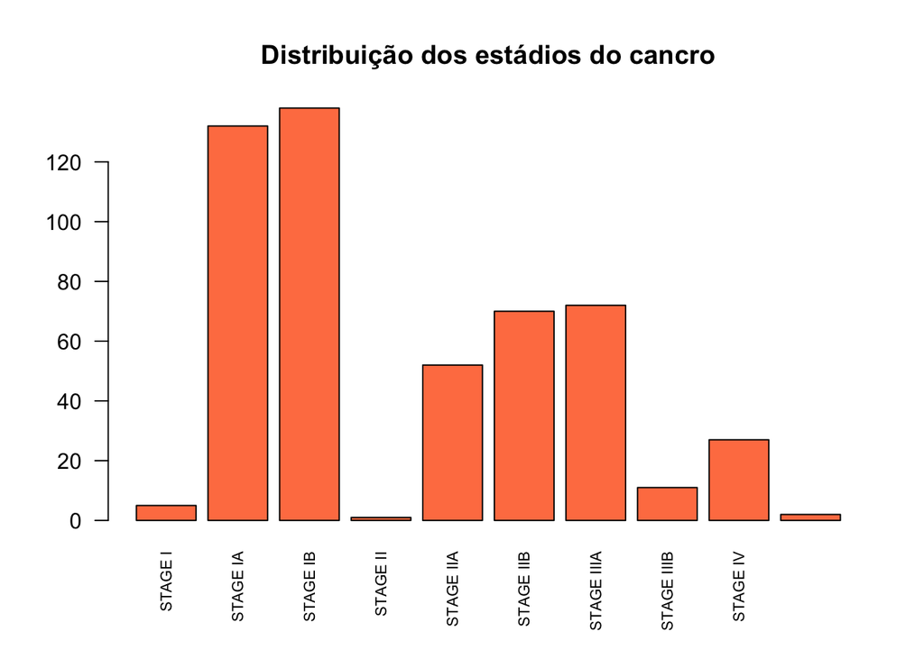

```
##
## Female   Male
##    274    236
```

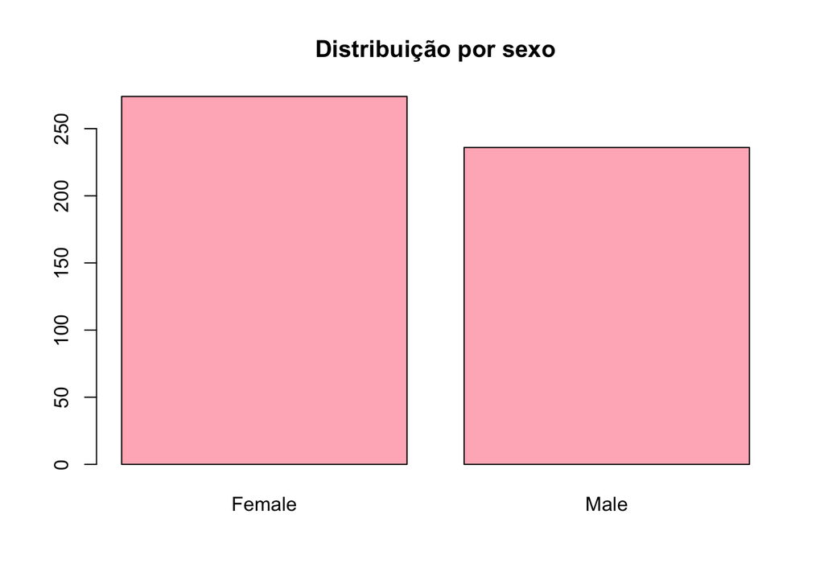

```
##
## DECEASED   LIVING
##      185      325
```

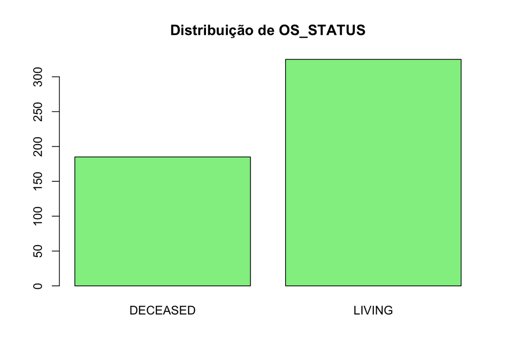

```
##
##    CENSORED PROGRESSION
##         304         206
```

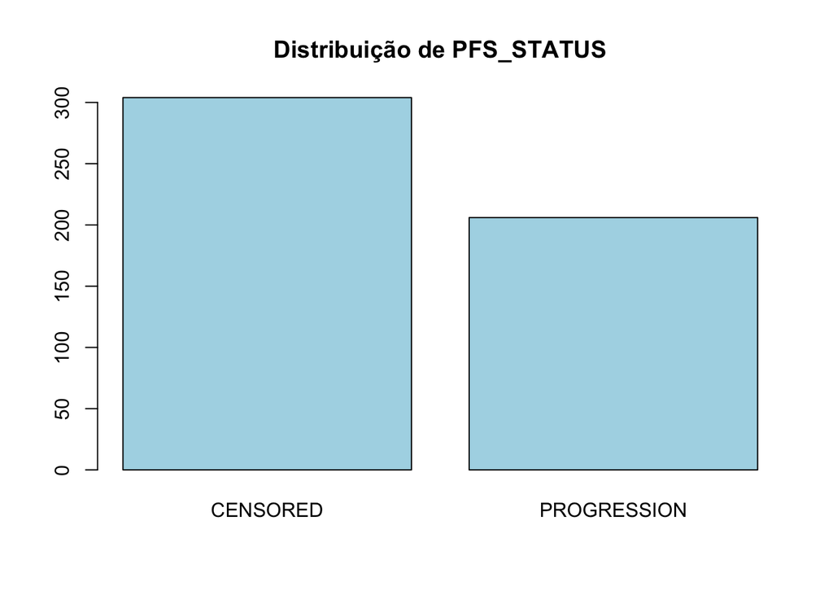

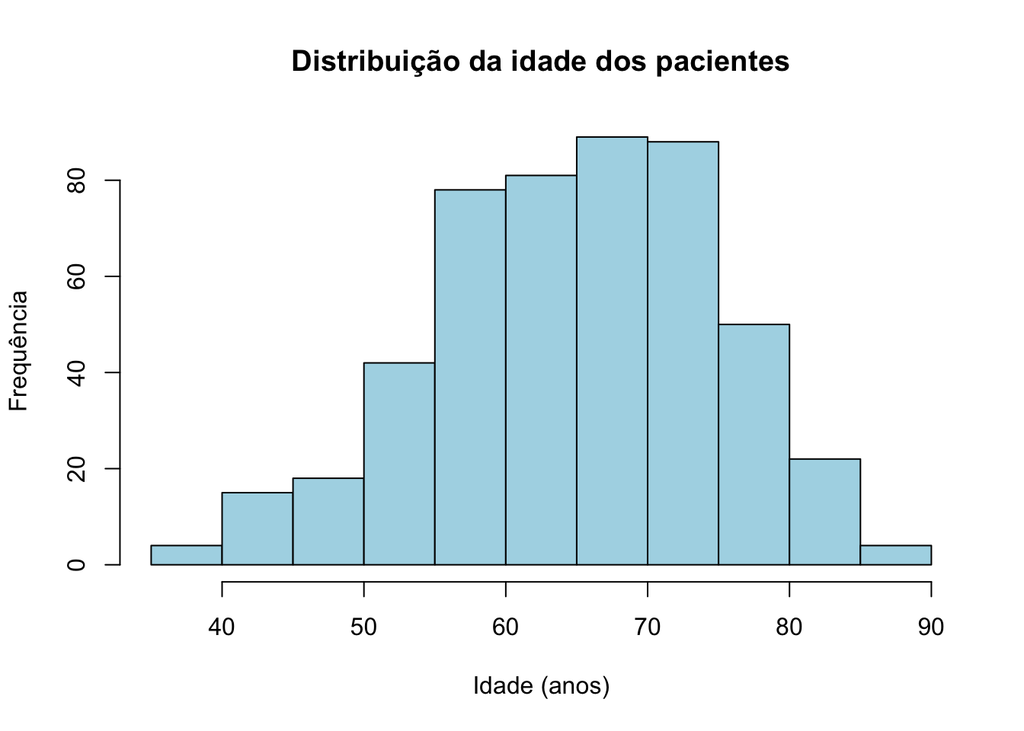

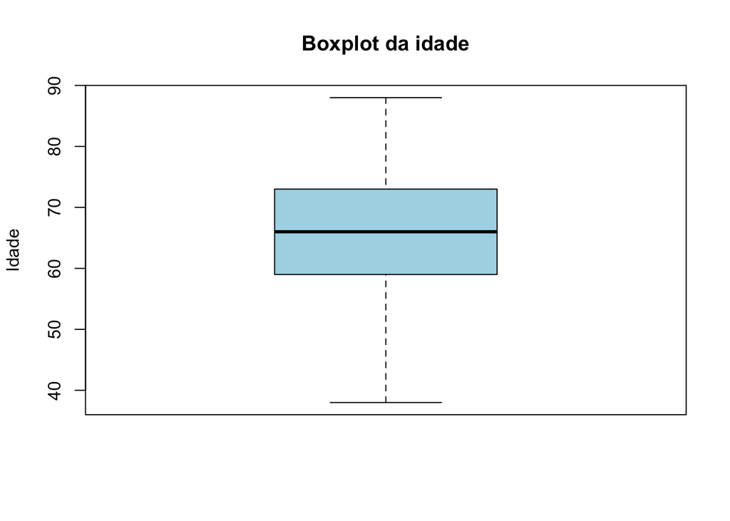

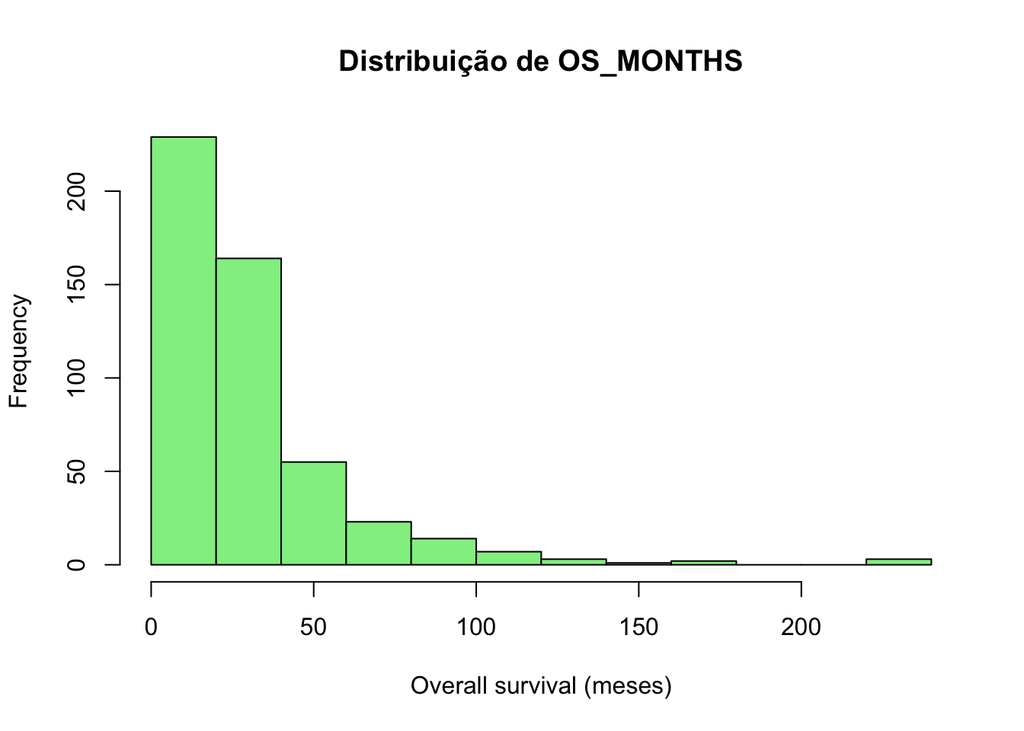

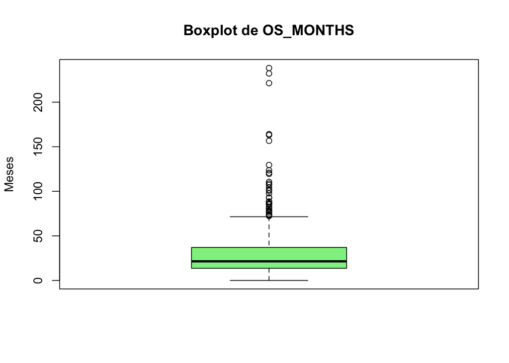

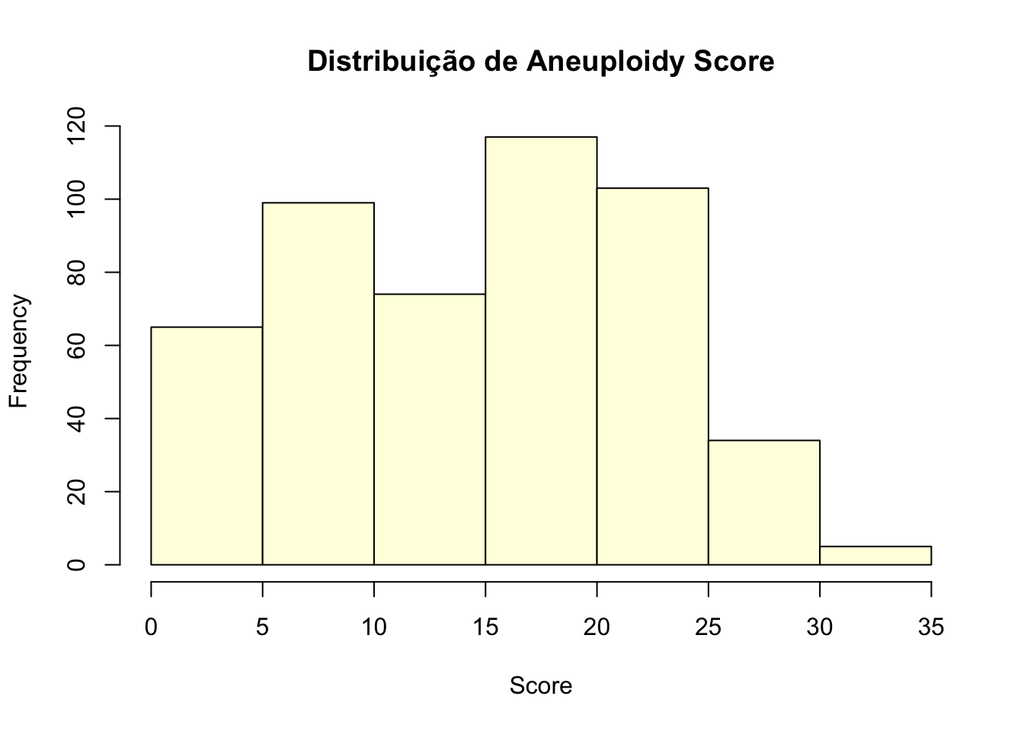

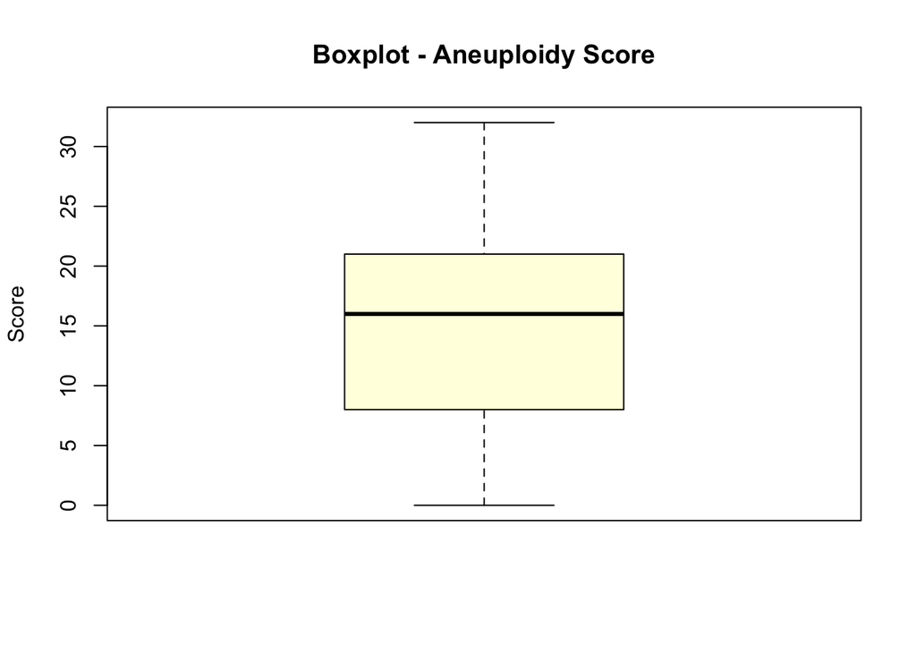

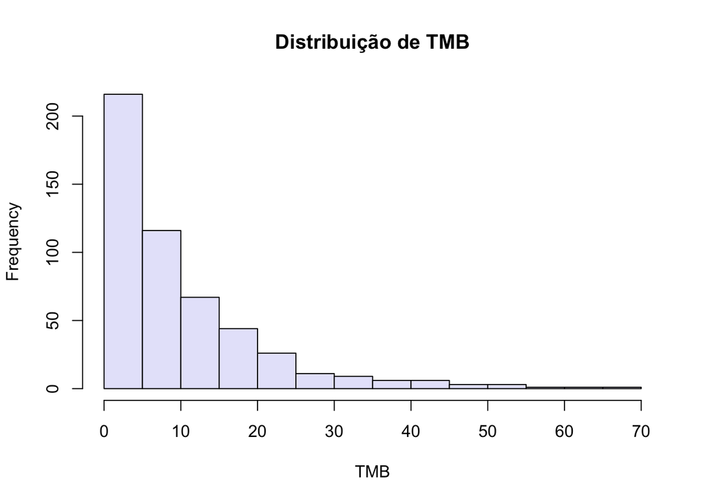

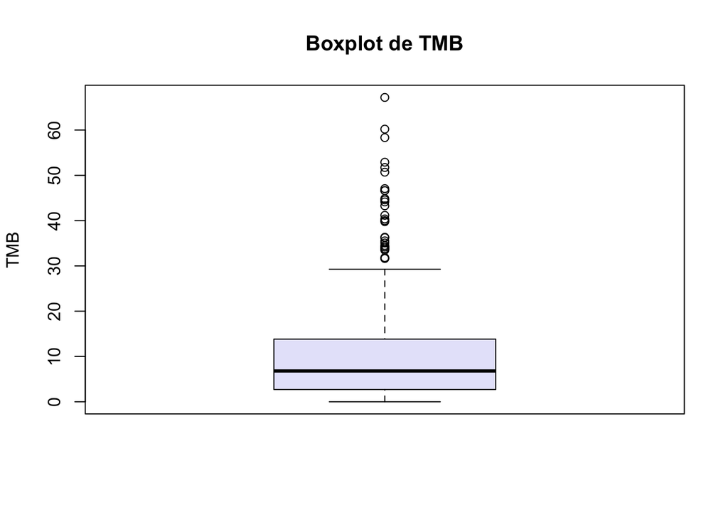

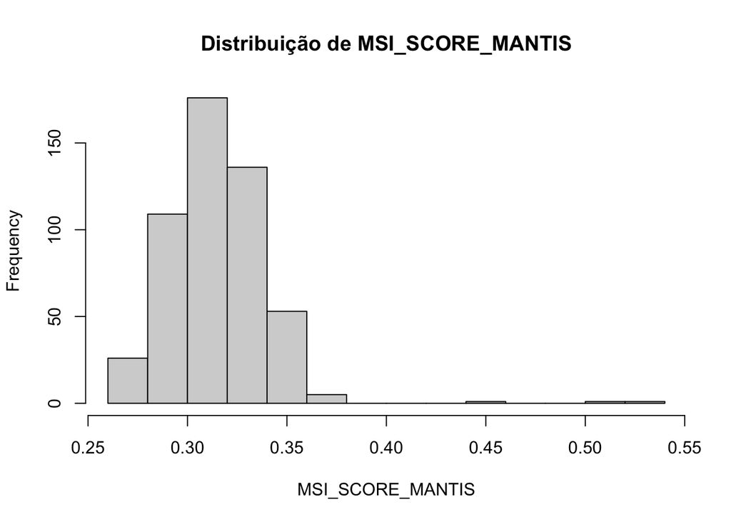

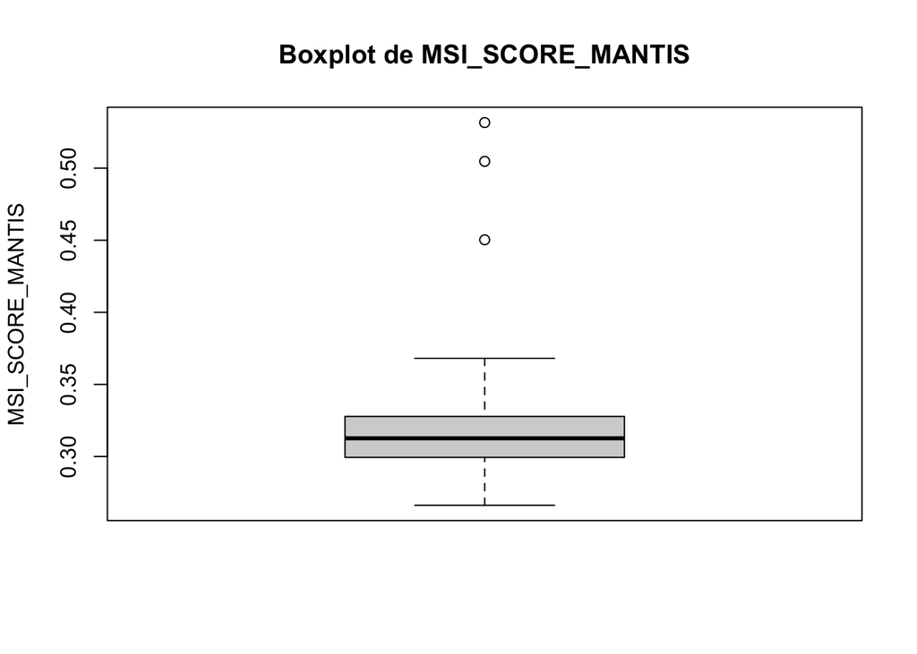

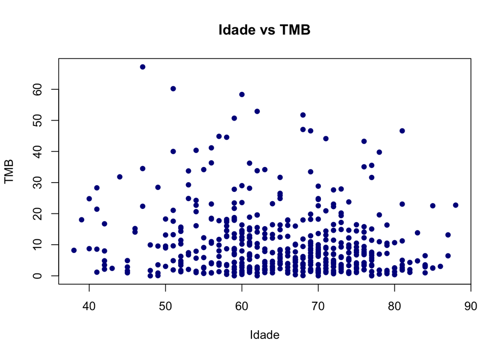

[3 more figures not shown]

```
##
## Resumo das medianas por amostra:
##    Min. 1st Qu.  Median    Mean 3rd Qu.    Max.
##   4.256   5.382   5.674   5.643   5.944   6.629
##
## Resumo das médias por amostra:
##    Min. 1st Qu.  Median    Mean 3rd Qu.    Max.
##   4.662   5.361   5.576   5.567   5.784   6.364
##
## Resumo dos desvios padrão por amostra:
##    Min. 1st Qu.  Median    Mean 3rd Qu.    Max.
##   3.124   3.424   3.478   3.477   3.539   3.768
```

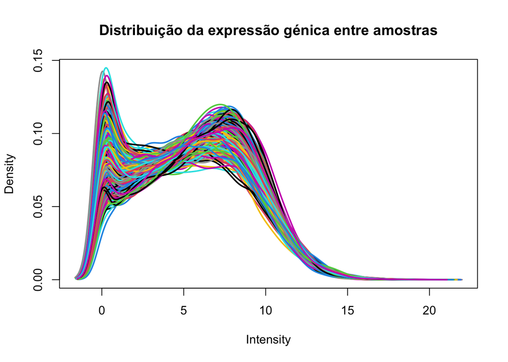

### Análises dos gráficos #### Distribuição dos estádios do cancro

Observa-se uma distribuição assimétrica dos estádios tumorais, com maior concentração de pacientes nos estádios iniciais (Stage IA e IB). Os estádios intermédios (IIA, IIB, IIIA) apresentam frequências moderadas, enquanto os estádios mais avançados (IIIB e IV) são menos representados. Esta distribuição sugere um possível viés de amostragem ou diagnóstico precoce predominante.

#### Distribuição por sexo

A variável sexo apresenta uma distribuição relativamente equilibrada entre os grupos, com ligeira predominância de pacientes do sexo feminino. Este equilíbrio reduz o risco de viés associado ao sexo em análises comparativas.

#### Boxplot da idade

O boxplot da idade revela uma mediana situada aproximadamente nos 65 anos, com intervalo interquartil concentrado entre cerca de 58 e 72 anos. Observa-se uma dispersão moderada e ausência de outliers extremos significativos, indicando uma distribuição relativamente estável. A simetria aproximada sugere que a média e a mediana são próximas, reforçando a consistência da variável.

#### Distribuição de OS_MONTHS

A variável OS_MONTHS apresenta uma distribuição fortemente assimétrica à direita, com elevada concentração de observações em valores baixos e uma cauda longa para valores elevados. Este padrão é típico de dados de sobrevivência, refletindo a presença de variabilidade no tempo até ao evento.

#### Boxplot de OS_MONTHS

O boxplot evidencia uma mediana relativamente baixa e uma elevada presença de outliers superiores, correspondentes a pacientes com longos tempos de sobrevivência. A amplitude interquartil é reduzida comparativamente à extensão total dos dados, reforçando a assimetria positiva da distribuição. Estes resultados sugerem heterogeneidade clínica significativa na sobrevivência dos pacientes.

#### Distribuição da TMB

A distribuição da carga mutacional tumoral (TMB) é fortemente assimétrica à direita, com elevada concentração de valores baixos e presença de uma cauda longa. Este padrão é consistente com dados genómicos, onde a maioria dos tumores apresenta baixa carga mutacional, enquanto um subconjunto reduzido apresenta valores elevados.

#### Boxplot da TMB

O boxplot confirma a assimetria positiva da distribuição, com múltiplos outliers superiores representando amostras com elevada carga mutacional. A mediana situa-se em valores baixos, enquanto a dispersão superior é significativamente maior do que a inferior, refletindo heterogeneidade entre pacientes.

#### Distribuição da MSI_SCORE_MANTIS

A variável MSI_SCORE_MANTIS apresenta uma distribuição concentrada num intervalo estreito, com ligeira assimetria à direita e presença de poucos valores extremos. A maioria das observações situa-se em torno de valores próximos, sugerindo baixa variabilidade global nesta métrica.

#### Boxplot da MSI_SCORE_MANTIS

O boxplot evidencia uma distribuição compacta, com mediana central e reduzida amplitude interquartil. A presença de alguns outliers superiores indica a existência de casos com maior instabilidade, embora estes sejam pouco frequentes.

#### Idade vs TMB

A análise de dispersão entre idade e TMB não revela uma relação linear evidente entre as variáveis. Os pontos encontram-se dispersos ao longo do eixo da idade, com variabilidade de TMB em praticamente todas as faixas etárias. Este padrão sugere ausência de correlação forte, indicando que a carga mutacional não depende diretamente da idade nesta coorte.

#### Idade vs MSI_SCORE_MANTIS

A relação entre idade e MSI_SCORE_MANTIS não apresenta tendência linear clara. A distribuição dos pontos indica independência entre as variáveis, com valores de MSI relativamente constantes ao longo das diferentes idades, sugerindo ausência de associação significativa.

#### TMB vs Estádio

A comparação da TMB entre diferentes estádios tumorais revela variação na distribuição dos valores, com tendência para maior dispersão em alguns estádios intermédios e avançados. Embora as medianas não apresentem diferenças abruptas entre grupos, a presença de outliers sugere heterogeneidade intra-estádio.

#### TMB vs Sexo

A distribuição da TMB por sexo revela padrões semelhantes entre os grupos masculino e feminino, com medianas próximas e amplitudes interquartis comparáveis. Ambos os grupos apresentam outliers superiores, indicando presença de indivíduos com elevada carga mutacional. Globalmente, não se observam diferenças substanciais entre sexos.

#### PCA dos dados de expressão

A análise de componentes principais (PCA) evidencia que os dois primeiros componentes (PC1 e PC2) explicam uma proporção limitada da variabilidade total (≈10.3% e 6.2%, respetivamente). A projeção das amostras não revela separação clara entre os grupos etários, sugerindo ausência de estrutura dominante associada à idade nos dados de expressão génica. A dispersão homogénea dos pontos indica elevada complexidade e dimensionalidade dos dados, sendo provável que a variabilidade esteja distribuída por múltiplos componentes.

## Análise estatística e expressão diferencial

```r
source("../scripts/06_statistical_analysis.R")
```

```
## Distribuição de STAGE_GROUP:
##
##    Early Advanced     <NA>
##      398      110        2
##
## Número de amostras usadas no modelo: 489
## Dimensão da matriz de expressão: 9210 489
##
## Distribuição final de STAGE_GROUP:
##
##    Early Advanced
##      383      106
##
## Distribuição final de SEX:
##
## Female   Male
##    264    225
##
## Matriz de desenho:
##                 X.Intercept. STAGE_GROUPAdvanced AGE SEXMale
## TCGA-05-4244-01            1                   1  70       1
## TCGA-05-4249-01            1                   0  67       1
## TCGA-05-4250-01            1                   1  79       0
## TCGA-05-4382-01            1                   0  68       1
## TCGA-05-4384-01            1                   1  66       1
## TCGA-05-4389-01            1                   0  70       1
##
## Número total de genes analisados: 9210
## Genes com adj.P.Val < 0.05: 94
## Genes com adj.P.Val < 0.01: 0
```

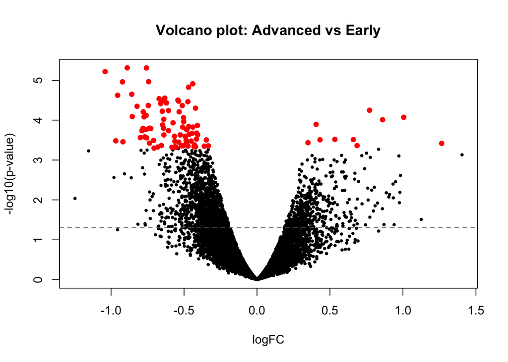

```
##
## Top 20 genes mais significativos:
##                Gene      logFC  AveExpr         t      P.Value  adj.P.Val
## TNFRSF13B TNFRSF13B -0.8887334 3.861352 -4.621361 4.878591e-06 0.01863052
## STAP1         STAP1 -0.7576558 4.168681 -4.620583 4.896159e-06 0.01863052
## CD19           CD19 -1.0405907 5.252010 -4.573907 6.068574e-06 0.01863052
## LINC00494 LINC00494 -0.7423251 2.380688 -4.445095 1.087038e-05 0.01879634
## KIAA0125   KIAA0125 -0.9215696 5.821419 -4.443028 1.097130e-05 0.01879634
## CBX7           CBX7 -0.4403930 9.128954 -4.418391 1.224517e-05 0.01879634
## FGD3           FGD3 -0.4687081 7.861600 -4.373528 1.493712e-05 0.01965298
## CD79A         CD79A -0.8580702 8.511967 -4.280546 2.242698e-05 0.02069972
## TMEM130     TMEM130 -0.9548179 7.075107 -4.266478 2.383400e-05 0.02069972
## PATL2         PATL2 -0.6320752 3.991045 -4.229066 2.799744e-05 0.02069972
## TNFRSF13C TNFRSF13C -0.6706743 3.395824 -4.220419 2.905408e-05 0.02069972
## SEPT1         SEPT1 -0.5419982 7.476826 -4.202265 3.139719e-05 0.02069972
## CD27           CD27 -0.6464490 7.782981 -4.190801 3.296852e-05 0.02069972
## ACSS1         ACSS1 -0.5372242 9.649908 -4.187719 3.340362e-05 0.02069972
## PBX4           PBX4 -0.4736805 4.672745 -4.180560 3.443541e-05 0.02069972
## MEI1           MEI1 -0.6206141 6.677502 -4.164072 3.692836e-05 0.02069972
## DHDH           DHDH -0.6601087 4.660213 -4.154561 3.844361e-05 0.02069972
## PNOC           PNOC -0.7447715 4.428596 -4.128747 4.286012e-05 0.02069972
## DNAH8         DNAH8 -0.5121904 1.844292 -4.127547 4.307690e-05 0.02069972
## TNFRSF17   TNFRSF17 -0.8219354 5.484664 -4.117401 4.495053e-05 0.02069972
##                  B
## TNFRSF13B 3.787883
## STAP1     3.784694
## CD19      3.594338
## LINC00494 3.078171
## KIAA0125  3.069997
## CBX7      2.972856
## FGD3      2.797234
## CD79A     2.438501
## TMEM130   2.384846
## PATL2     2.242949
## TNFRSF13C 2.210314
## SEPT1     2.142006
## CD27      2.099009
## ACSS1     2.087467
## PBX4      2.060690
## MEI1      1.999182
## DHDH      1.963803
## PNOC      1.868163
## DNAH8     1.863727
## TNFRSF17  1.826299
```

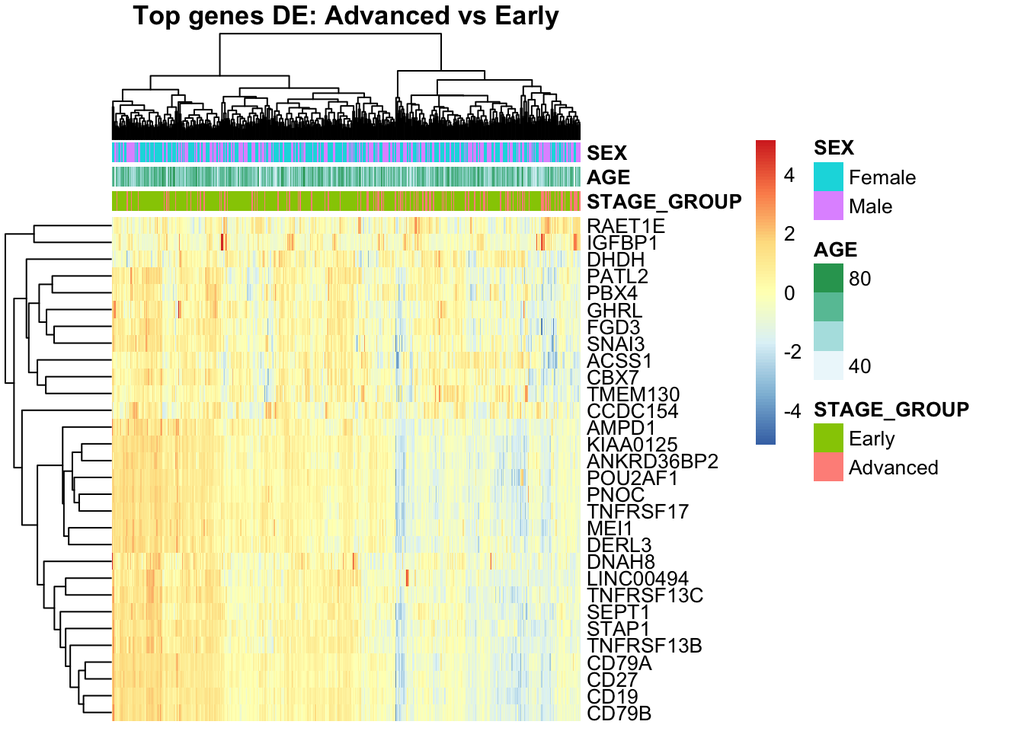

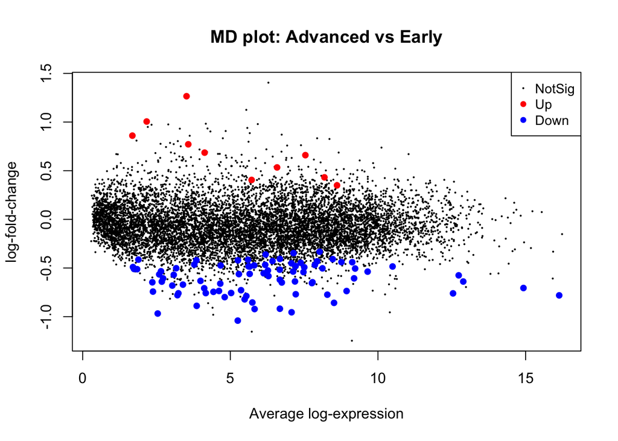

### Volcano plot: Advanced vs Early

A análise de expressão diferencial foi realizada comparando amostras de estádios tumorais avançados com amostras de estádios iniciais, ajustando simultaneamente para idade e sexo. O volcano plot mostra a distribuição dos genes segundo o logFC e a significância estatística. Os pontos destacados a vermelho correspondem a genes diferencialmente expressos com maior evidência estatística. Observa-se um número limitado de genes significativos, sugerindo que as diferenças globais entre estádios existem, mas não são massivas à escala de todo o transcriptoma. Ainda assim, os genes identificados apontam para alterações transcricionais específicas associadas à progressão tumoral.

### Heatmap dos genes diferencialmente expressos

O heatmap foi construído com os genes diferencialmente expressos mais significativos no contraste entre estádios avançados e iniciais, com ajuste para idade e sexo. A organização hierárquica dos genes e das amostras permite observar padrões de expressão coordenados em subconjuntos de genes. Globalmente, não se verifica uma separação absolutamente nítida entre todas as amostras, o que é expectável em dados tumorais devido à elevada heterogeneidade biológica. No entanto, o heatmap evidencia blocos de genes com perfis de expressão distintos, sugerindo a existência de assinaturas moleculares associadas ao estádio tumoral.

## Interpretação biológica

```r
source("../scripts/07_enrichment_analysis.R")
```

```
## clusterProfiler v4.18.4 Learn more at https://yulab-smu.top/contribution-knowledge-mining/
##
## G Yu. Thirteen years of clusterProfiler. The Innovation. 2024,
## 5(6):100722
```

[output not shown]

```
## Genes com ENTREZ após conversão: 8003
## Genes no universo: 8003
## Genes significativos com ENTREZ: 87
## gene_list é numérico: TRUE
## NAs em gene_list: 0
## NAs nos nomes: 0
## Nomes vazios: 0
## Duplicados nos nomes: 0
```

```
## Reading KEGG annotation online: "https://rest.kegg.jp/link/hsa/pathway"...
```

```
## Reading KEGG annotation online: "https://rest.kegg.jp/list/pathway/hsa"...
```

```
##
## Top vias KEGG:
##                    category    subcategory       ID
## hsa05340     Human Diseases Immune disease hsa05340
## hsa04672 Organismal Systems  Immune system hsa04672
## hsa04662 Organismal Systems  Immune system hsa04662
##                                           Description GeneRatio BgRatio
## hsa05340                     Primary immunodeficiency      4/40 25/3631
## hsa04672 Intestinal immune network for IgA production      4/40 38/3631
## hsa04662            B cell receptor signaling pathway      4/40 40/3631
##          RichFactor FoldEnrichment   zScore       pvalue   p.adjust     qvalue
## hsa05340  0.1600000      14.524000 7.160410 0.0001352652 0.01176807 0.01167552
## hsa04672  0.1052632       9.555263 5.594640 0.0007118229 0.02515521 0.02495738
## hsa04662  0.1000000       9.077500 5.420943 0.0008674212 0.02515521 0.02495738
##                         geneID Count
## hsa05340  23495/930/973/115650     4
## hsa04672 23495/115650/608/3112     4
## hsa04662       930/973/974/640     4
```

```
##
## Via escolhida para pathview: 04110 - Cell cycle
```

```
## Info: Working in directory /Users/dianaoliveira/Desktop/fase_2_1/reports
```

```
## Info: Writing image file hsa04110.stage_age_sex.png
```

```
## Mapa KEGG gerado para a via: 04110 - Cell cycle
```